# BSCB_demo

2026-04-15

# Bayesian simultaneous credible bands for the polynomial model

## Overview

This demo illustrates how to use the **BSCB** package to construct and evaluate Bayesian simultaneous credible bands (BSCB) and Bayesian pointwise credible bands (BPCB) for polynomial regression. These methods are demonstrated:

- **BSCB-C**: BSCB under the Normal-Gamma conjugate prior
- **BSCB-H**: BSCB under the non-conjugate prior implemented via HMC
- **BSCB-I-J**: BSCB under the independent Jeffreys prior
- **BPCB-I-J**: BPCB under the independent Jeffreys prior

```r
library(BSCB)
```

## 1. Simulate Data

We simulate data from a quadratic regression model $Y_i = \theta_0 + \theta_1 x_i + \theta_2 x_i^2 + \varepsilon_i$, where $\varepsilon_i \sim N(0, \sigma^2)$.

```r
# Simulate data from a quadratic model using a D-optimal covariate design
theta_true <- c(-6, -3, 0.25)
alpha <- 0.05
a <- -0.5
b <- 0.5
L <- 500000
p <- 2
n <- 20
e_sd <- 0.2

sim_data <- generate_simulation_data(
   p           = p,
   n           = n,
   e_sd        = e_sd,
   theta_true  = theta_true,
   a           = a,
   b           = b,
   replication = 1,
   design_index = 2,
   center_index = 1
)
```

[output not shown]

```r
X <- sim_data$X
x <- sim_data$X[,2]
Y <- as.numeric(sim_data$Y.list[[1]])
```

```r
# You could also generate data in the simple way
# set.seed(123)
# n <- 20
# x <- seq(-0.5, 0.5, length.out = n)
# X <- cbind(1, x, x^2)
# theta_true <- c(-6, -3, 0.25)
# Y <- as.numeric(X %*% theta_true + rnorm(n, sd = 0.2))
```

## 2. Construct the Bands

### BSCB-C: BSCB under the Normal-Gamma conjugate prior

The Normal-Gamma conjugate prior supports three hyperparameter specifications: `"empirical"` (empirical Bayes), `"unit_info"` (unit-information prior), and `"g_prior"` (Zellner’s g-prior). The critical constant $\lambda$ is estimated via $L = 500{,}000$ Monte Carlo draws.

```r
# --- BSCB-C: Bayesian simultaneous credible bands under the Normal-Gamma conjugate prior ---
fit_c <- compute_bscb_conjugate(
  X              = X,
  Y              = Y,
  alpha          = alpha,
  a              = a,
  b              = b,
  L              = L,
  theta_true     = theta_true,
  hyperparameter = "g_prior",   # "empirical", "unit_info", or "g_prior"
  optimize_type  = "P"          # "P" = polyroot (recommended)
)
```

```
## Computing lambda via Monte Carlo sampling...
```

```
## The critical constant lambda = 2.625759
```

```r
cat("Critical constant (BSCB-C):", fit_c$lambda, "\n")
```

```
## Critical constant (BSCB-C): 2.625759
```

```r
cat("Posterior mean of theta:\n")
```

```
## Posterior mean of theta:
```

```r
print(round(fit_c$mu_star, 4))
```

```
## [1] -6.0383 -3.0610  0.4922
```

### BSCB-I-J: BSCB under the independent Jeffreys prior

BSCB-I-J is equivalent to the FSCB in Liu et al.(2008) for finite sample sizes.

```r
# --- BSCB-I-J: Bayesian simultaneous credible bands under the Independent Jeffreys prior ---
fit_j <- compute_bscb_ind_jeffreys(
  X     = X,
  Y     = Y,
  alpha = alpha,
  a     = a,
  b     = b,
  theta_true = theta_true,
  L     = L
)
```

```
## Computing lambda via Monte Carlo sampling...
```

```
## The critical constant lambda = 2.642732
```

```r
cat("Critical constant (BSCB-J):", fit_j$lambda, "\n")
```

```
## Critical constant (BSCB-J): 2.642732
```

### BSCB-H-C: BSCB under the normal-half-Cauchy prior(0,2) implemented via HMC

```r
mod <- instantiate::stan_package_model(
  name    = "HMC_model",
  package = "BSCB",
  compile = TRUE
)
```

```r
# --- BSCB-H-C: BSCB under the normal-half-Cauchy prior(0,2) implemented via HMC ---

fit_h <- compute_bscb_hmc(
  X     = X,
  Y     = Y,
  V     = diag(n),
  alpha = alpha,
  a     = a,
  b     = b,
  theta_true = theta_true,
  prior_type = "normal_half_cauchy",
  L     = L,
  thin_number = 4,
  draw_num = 10000
)
```

```
## Running MCMC with 4 sequential chains...
##
## Chain 1 finished in 0.4 seconds.
## Chain 2 finished in 0.4 seconds.
## Chain 3 finished in 0.4 seconds.
## Chain 4 finished in 0.4 seconds.
##
## All 4 chains finished successfully.
## Mean chain execution time: 0.4 seconds.
## Total execution time: 1.8 seconds.
```

```r
cat("Critical constant (BSCB-H-C):", fit_h$lambda, "\n")
```

```
## Critical constant (BSCB-H-C): 2.47295
```

### BPCB-I-J: BPCB under the independent Jeffreys prior

BPCB-I-J is constructed by connecting confidence intervals at each individual points in the covariate domain. It’s also equivalent to the FPCB.

```r
# --- BPCB-I-J: Bayesian pointwise credible bands under the Independent Jeffreys prior ---
fit_p <- compute_bpcb_ind_jeffreys(
  X     = X,
  Y     = Y,
  alpha = alpha,
  a     = a,
  b     = b,
  theta_true = theta_true
)
```

```
## The critical constant lambda = 2.109816
```

## 3. Evaluate Bands over a Grid and Plot

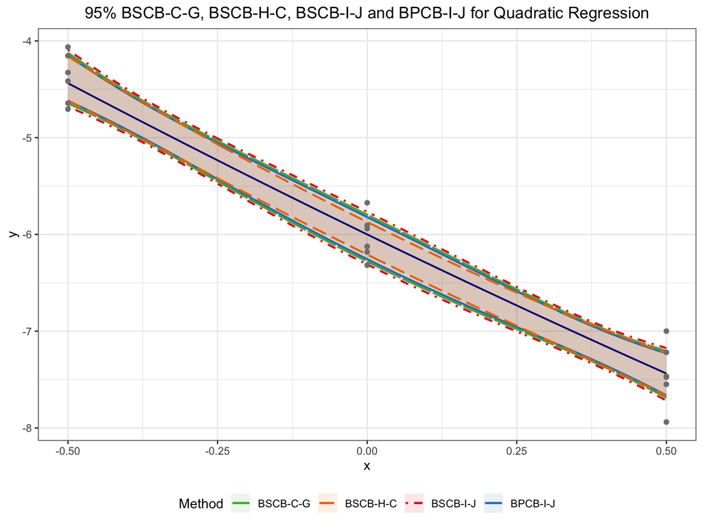

```r
library(ggplot2)
x_seq  <- seq(-0.5, 0.5, length.out = 500)
y_true <- as.numeric(cbind(1, x_seq, x_seq^2) %*% theta_true)
df_obs <- data.frame(x = x, Y = as.numeric(Y))

# Collect all band boundaries into a single data frame
df_bands <- data.frame(
  x       = rep(x_seq, 4),
  lower   = c(as.numeric(fit_c$lower_bound(x_seq)),
              as.numeric(fit_j$lower_bound(x_seq)),
              as.numeric(fit_h$lower_bound(x_seq)),
              as.numeric(fit_p$lower_bound(x_seq))),
  upper   = c(as.numeric(fit_c$upper_bound(x_seq)),
              as.numeric(fit_j$upper_bound(x_seq)),
              as.numeric(fit_h$upper_bound(x_seq)),
              as.numeric(fit_p$upper_bound(x_seq))),
  method  = rep(c("BSCB-C-G",
                  "BSCB-I-J",
                  "BSCB-H-C",
                  "BPCB-I-J"),
                each = length(x_seq))
)

df_true <- data.frame(x = x_seq, y = y_true)

band_colours <- c(
  "BSCB-C-G" = "#4DAF4A",
  "BSCB-I-J" = "#E41A1C",
  "BSCB-H-C" = "darkorange2",
  "BPCB-I-J" = "#377EB8"
)

band_linetypes <- c(
  "BSCB-C-G" = "F1",
  "BSCB-I-J" = "dotdash",
  "BSCB-H-C" = "longdash",
  "BPCB-I-J" = "solid"
)

ggplot() +
  # Shaded credible regions
  geom_ribbon(
    data    = df_bands,
    mapping = aes(x = x, ymin = lower, ymax = upper,
                  fill = method),
    alpha   = 0.10
  ) +
  # Band boundaries
  geom_line(
    data    = df_bands,
    mapping = aes(x = x, y = lower,
                  colour   = method,
                  linetype = method),
    linewidth = 0.8
  ) +
  geom_line(
    data    = df_bands,
    mapping = aes(x = x, y = upper,
                  colour   = method,
                  linetype = method),
    linewidth = 0.8
  ) +
  # True regression curve
  geom_line(
    data      = df_true,
    mapping   = aes(x = x, y = y),
    colour    = "navyblue",
    linewidth = 0.7,
    linetype  = "solid"
  ) +
  # Observed data
  geom_point(
    data    = df_obs,
    mapping = aes(x = x, y = Y),
    colour  = "gray50",
    size    = 1.5
  ) +
  scale_colour_manual(
  values = band_colours,
  name   = "Method",
  breaks = c("BSCB-C-G", "BSCB-H-C", "BSCB-I-J", "BPCB-I-J")) +
  scale_fill_manual(
  values = band_colours,
  name   = "Method",
  breaks = c("BSCB-C-G", "BSCB-H-C", "BSCB-I-J", "BPCB-I-J")) +
  scale_linetype_manual(
  values = band_linetypes,
  name   = "Method",
  breaks = c("BSCB-C-G", "BSCB-H-C", "BSCB-I-J", "BPCB-I-J")) +
  labs(
    title = "95% BSCB-C-G, BSCB-H-C, BSCB-I-J and BPCB-I-J for Quadratic Regression",
    x     = "x",
    y     = "y"
  ) +
  theme_bw() +
  theme(legend.position = "bottom",
        plot.title      = element_text(hjust = 0.5))
```

## 4. Evaluate Coverage

### Empirical Simultaneous Coverage Rate (ESCR)

`coverage_ESCR()` returns 1 if the true regression function lies within the band at all points in $[a, b]$, and 0 otherwise.

```r
escr_j <- coverage_ESCR(fit_j, optimize_type = "P", verbose = TRUE)
escr_c <- coverage_ESCR(fit_c, optimize_type = "P", verbose = TRUE)
escr_h <- coverage_ESCR(fit_h, optimize_type = "P", verbose = TRUE)
escr_p <- coverage_ESCR(fit_p, optimize_type = "P", verbose = TRUE)

cat("ESCR (BSCB-I-J):", escr_j, "\n")
```

```
## ESCR (BSCB-I-J): 1
```

```r
cat("ESCR (BSCB-C-G):", escr_c, "\n")
```

```
## ESCR (BSCB-C-G): 1
```

```r
cat("ESCR (BSCB-H-C):", escr_h, "\n")
```

```
## ESCR (BSCB-H-C): 1
```

```r
cat("ESCR (BPCB-I-J):", escr_p, "\n")
```

```
## ESCR (BPCB-I-J): 1
```

### Posterior Simultaneous Coverage Probability (PSCP)

`coverage_PSCP()` estimates the proportion of posterior draws for which $\sup_{x \in [a,b]} T(x) \leq \lambda$.

```r
pscp_j <- coverage_PSCP(fit_j, draw_num = 10000,
                         optimize_type = "P", verbose = TRUE)
```

```
## PSCP = 0.9458
```

```r
pscp_c <- coverage_PSCP(fit_c, draw_num = 10000,
                         optimize_type = "P", verbose = TRUE)
```

```
## PSCP = 0.9526
```

```r
pscp_h <- coverage_PSCP(fit_h, draw_num = 10000,
                         optimize_type = "P", verbose = TRUE)
```

```
## PSCP = 0.9482
```

```r
pscp_p <- coverage_PSCP(fit_p, draw_num = 10000,
                         optimize_type = "P", verbose = TRUE)
```

```
## PSCP = 0.8599
```

```r
cat("PSCP (BSCB-I-J):", round(pscp_j, 4), "\n")
```

```
## PSCP (BSCB-I-J): 0.9458
```

```r
cat("PSCP (BSCB-C-G):", round(pscp_c, 4), "\n")
```

```
## PSCP (BSCB-C-G): 0.9526
```

```r
cat("PSCP (BSCB-H-C):", round(pscp_h, 4), "\n")
```

```
## PSCP (BSCB-H-C): 0.9482
```

```r
cat("PSCP (BPCB-I-J):", round(pscp_p, 4), "\n")
```

```
## PSCP (BPCB-I-J): 0.8599
```

### Summary Table

```r
summary_tab <- data.frame(
  Method   = c("BSCB-C-G","BSCB-H-C", "BSCB-I-J"),
  Lambda   = round(c(fit_c$lambda,fit_h$lambda, fit_j$lambda), 4),
  ESCR     = c(escr_c,escr_h, escr_j),
  PSCP     = round(c(pscp_c,pscp_h, pscp_j), 4)
)
knitr::kable(summary_tab, caption = "Coverage summary for one simulated dataset")
```

Coverage summary for one simulated dataset

| Method | Lambda | ESCR | PSCP |
| --- | --- | --- | --- |
| BSCB-C-G | 2.6258 | 1 | 0.9526 |
| BSCB-H-C | 2.4729 | 1 | 0.9482 |
| BSCB-I-J | 2.6427 | 1 | 0.9458 |